# Machine Learning Project

Jagadeesha

Sep 2, 2018

## Background

Using devices such as Jawbone Up, Nike FuelBand, and Fitbit it is now possible to collect a large amount of data about personal activity relatively inexpensively. These type of devices are part of the quantified self movement - a group of enthusiasts who take measurements about themselves regularly to improve their health, to find patterns in their behavior, or because they are tech geeks. One thing that people regularly do is quantify how much of a particular activity they do, but they rarely quantify how well they do it. In this project, our goal will be to use data from accelerometers on the belt, forearm, arm, and dumbell of 6 participants. They were asked to perform barbell lifts correctly and incorrectly in 5 different ways. More information is available from the website here: http://web.archive.org/web/20161224072740/http:/groupware.les.inf.puc-rio.br/har (see the section on the Weight Lifting Exercise Dataset).

## Libraries

```r
suppressMessages(library(caret))
suppressMessages(library(rattle))
```

```r
suppressMessages(library(rpart))
suppressMessages(library(rpart.plot))
suppressMessages(library(RColorBrewer))
suppressMessages(library(randomForest))
suppressMessages(library(corrplot))
```

## Data loading

First, we load the data from provided url. If the file is already downloaded and stored in the local machine, then the downloaded file will be used instead of downloading the files again.

```r
wd <- getwd()
trainingFile <- paste0(wd,"/pml-training.csv")
testingFile <-  paste0(wd,"/pml-testing.csv")

if(!file.exists(trainingFile) | !file.exists(testingFile)) {
  download.file("https://d396qusza40orc.cloudfront.net/predmachlearn/pml-training.csv",
                destfile="pml-training.csv",method="libcurl")
  download.file("https://d396qusza40orc.cloudfront.net/predmachlearn/pml-testing.csv",
                destfile="pml-testing.csv",method="libcurl")
}
trainDataComplete <- read.csv(trainingFile, na.strings=c("NA","#DIV/0!",""), header=TRUE)
testDataComplete <- read.csv(testingFile,  na.strings=c("NA","#DIV/0!",""), header = TRUE)

dim(trainDataComplete)
```

```
## [1] 19622   160
```

```r
dim(testDataComplete)
```

```
## [1]  20 160
```

The training dataset contains 19622 observations of 160 variables. The test dataset contains 20 observations of 160 variables.

## Cleaning the data

The first 7 columns of the dataset contain the information about the users and the timestamp. Since we are not interested in these information, we can ignore those 7 columns.

```r
trainData <- trainDataComplete[,-c(1:7)]
```

The near zero variance variables can be removed using nearZeroVar function. There are plenty of columns with missing values. So we ignore the columns which have more than 80% of missing values.

```r
nzv <- nearZeroVar(trainData)
trainData <- trainData[, -nzv]
n <- dim(trainData)[1]
naLimit <- n * 0.8
colSum <- colSums(is.na(trainData)|trainData=="")
colsToRemove <- which(colSum > naLimit)
trainData <- trainData[,-(colsToRemove)]

dim(trainData)
```

```
## [1] 19622    53
```

## Partition the training set into training and testing.

```r
set.seed(3344)
inTrainData <- createDataPartition(trainData$classe, p=0.6, list=FALSE)
training <- trainData[inTrainData, ]
testing <- trainData[-inTrainData, ]
```

## Prediction with decision trees

We use the decision trees algorithm for prediction on the `training` dataset. We use trainControl method to set the cross validation of the model.

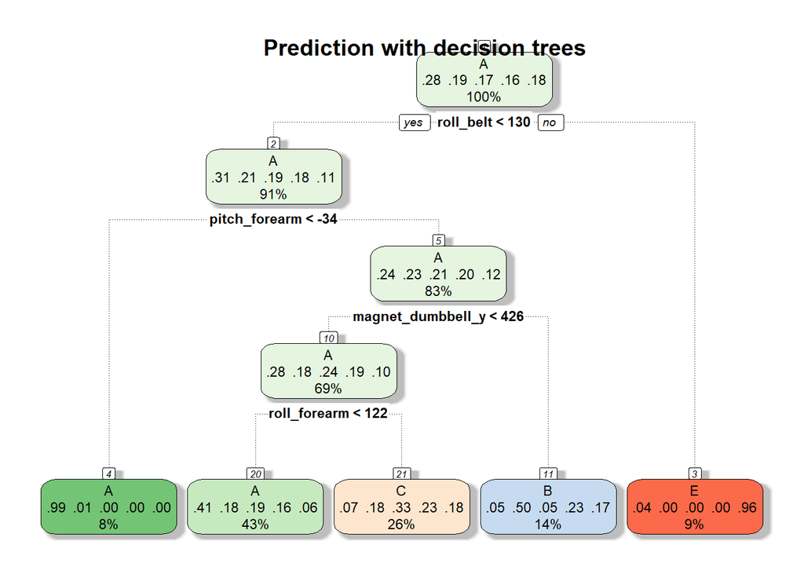

```r
#Decision Trees
set.seed(3344)
tc <- trainControl(method="cv", number=5)
dtModel <- train(classe ~ ., method = "rpart", data = training, trControl = tc)
fancyRpartPlot(dtModel$finalModel, main="Prediction with decision trees", sub="")
```

```r
tPredict <- predict(dtModel,testing)
dtConfMatrix <- confusionMatrix(tPredict,testing$classe)
# display confusion matrix and model accuracy
dtConfMatrix$table
```

```
##           Reference
## Prediction    A    B    C    D    E
##          A 1977  599  606  582  197
##          B   45  532   54  235  211
##          C  178  387  708  469  375
##          D    0    0    0    0    0
##          E   32    0    0    0  659
```

```r
dtConfMatrix$overall[1]
```

```
##  Accuracy
## 0.4940097
```

As shown above, the accuracy of the model (0.4940097) is very low. We can tune the model to have better accuracy by using tuneLength or tuneGrid (by setting complexity parameter) properties. But since that is out of scope of this write up, we will explore other methods.

## Gradient boosting method

In this method, we change the method to `gbm`.

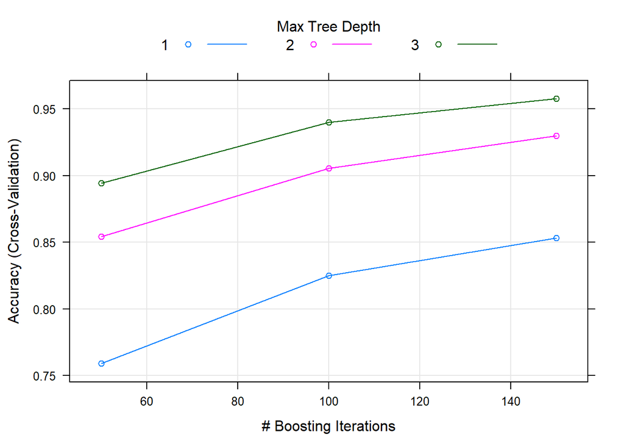

```r
set.seed(3344)
gbModel <- train(classe ~ ., method = "gbm", data = training, trControl = tc, verbose= FALSE )
plot(gbModel)
```

```r
tPredict <- predict(gbModel,newdata=testing)
gbConfMatrix <- confusionMatrix(tPredict,testing$classe)
gbConfMatrix$table
```

```
##           Reference
## Prediction    A    B    C    D    E
##          A 2200   56    0    0    5
##          B   23 1405   46    3   27
##          C    5   53 1302   47   18
##          D    4    2   17 1229   16
##          E    0    2    3    7 1376
```

```r
gbConfMatrix$overall[1]
```

```
##  Accuracy
## 0.9574305
```

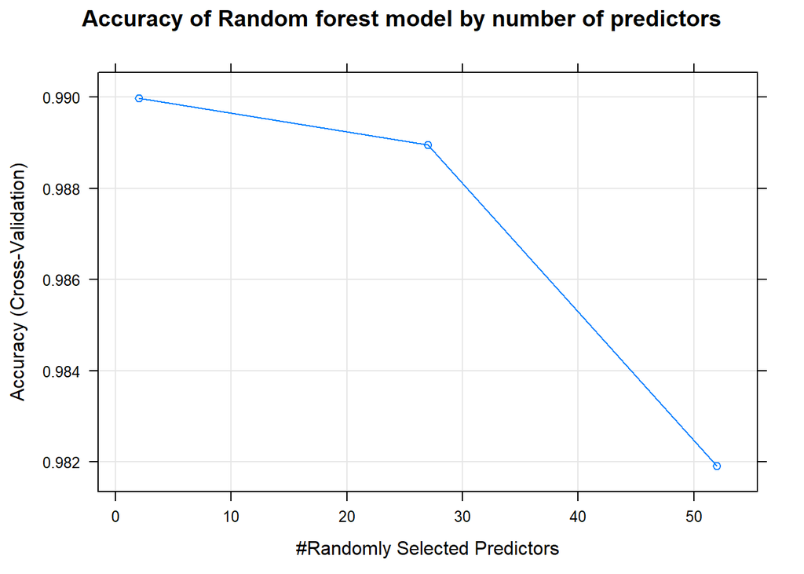

```r
set.seed(3344)
rfModel <- train(classe~., method="rf", data=training, trControl=tc, verbose=FALSE)
plot(rfModel,main="Accuracy of Random forest model by number of predictors")
```

```r
tPredict <- predict(rfModel,newdata=testing)
rfConfMatrix <- confusionMatrix(tPredict,testing$classe)
rfConfMatrix$table
```

```
##           Reference
## Prediction    A    B    C    D    E
##          A 2232    5    0    0    0
##          B    0 1507   10    0    0
##          C    0    6 1356   27    3
##          D    0    0    2 1259    4
##          E    0    0    0    0 1435
```

```r
rfConfMatrix$overall[1]
```

```
##  Accuracy
## 0.9927352
```

The accuracy of random forest model is 0.9927352, which indicates that the random forest model is better than decision trees and fradient boosting models. The expected out of sample error is 0.72648%.

## Model selection

The random forest model had better accuracy than the decision tree and gradient boosting models. So we will apply the random forest model on the test dataset.

```r
finalTest <- predict(rfModel,newdata=testDataComplete)
finalTest
```

```
##  [1] B A B A A E D B A A B C B A E E A B B B
## Levels: A B C D E
```

## Conclusion

Data cleaning process ensured most of the non zero variance values are ignored in the prediction models. Using random forest model, we are able to fit a reasonably good prediction model with high accuracy. The selected model is then applied on the test dataset. The model can be tuned to have more accuracy by using tuneLength or tuneGrid properties.